# Densely connected neural network

Kasper Dupont Toft Braun

27-04-2022

This notebook contains the script we’ve used for finding the most optimal neural network in terms of validation accuracy. This notebook calls multiple R scripts in order to test different combinations of hyperparameters

# Setup

```r
#### tfruns ####
library(keras)
library(tfruns)
library(tidyverse)
rm(list = ls())
setwd("C:/Users/kaspe/OneDrive - Aarhus Universitet/Skrivebord/BI/2. semester/Data science project/Data science project/Modeling/Neural Network/")
```

# Evaluation protocol

At first, I compared six models created by respectively k-fold cross validation and hold out validation to choose the best validation approach. I compared models with three hidden layers, where the first layer contained 128 neurons and the next two layers contained either 128, 64, or 32 neurons (1*3).

## Hold out validation

I start by checking the performance of hold out validation procedure.

```r
tp <- list(
  layers = c(3),
  units1 = c(128),
  units2 = c(128, 64, 32),
  batch_size = c(50),
  learning_rate = c(0.01),
  dropout = c(0),
  weight_decay = c(0)
)
```

```r
# Run combinations

runs <- tuning_run("tune_train_test.R", flags = tp, runs_dir = "runs_tune_train_test", confirm = FALSE, echo = FALSE)
```

```r
# Sort by val loss

runs %>%
  arrange(eval_best_loss) %>%
  select(eval_best_loss,
         eval_best_acc,
         eval_best_epoch,
         epochs_completed,
         flag_batch_size,
         flag_layers,
         flag_units1,
         flag_units2,
         flag_learning_rate,
         flag_dropout,
         flag_weight_decay,)
```

| eval_best_loss | eval_best_acc | eval_best_epoch | epochs_completed | flag_batch_size | flag_layers | flag_units1 | flag_units2 | flag_learning_rate | flag_dropout | flag_weight_decay |
| --- | --- | --- | --- | --- | --- | --- | --- | --- | --- | --- |
| 0.590 | 0.680 | 1 | 21 | 50 | 3 | 128 | 64 | 0.01 | 0 | 0 |
| 0.592 | 0.645 | 1 | 21 | 50 | 3 | 128 | 32 | 0.01 | 0 | 0 |
| 0.613 | 0.615 | 5 | 25 | 50 | 3 | 128 | 128 | 0.01 | 0 | 0 |

```r
# pull out the best valid loss run:

best_run_1 <- ls_runs(
  runs_dir = "runs_tune_train_test",
  order = eval_best_loss,
  decreasing = FALSE
) %>%
  slice(1) %>%
  pull(run_dir)


# View best run

view_run(best_run_1)

# Clean up a bit:
# save the best runs

copy_run(best_run_1, to = "best_runs_tune_train_test")

# archive the rest
#clean_runs(runs = ls_runs(runs_dir = "runs_tune_train_test"),
#           runs_dir = getOption("runs_tune_train_test", "runs_archive"),
#           confirm = interactive())

# clear the archive
# purge_runs()
```

## K-fold cross validation

Let’s now test how the K-fold cross-validation procedure performs.

```r
# Declare the flags that I want to tune

tp <- list(
  units1 = c(128),
  units2 = c(128, 64, 32)
)
```

```r
# Train a model with tfruns by using training_run()

runs <- tuning_run("new_k_fold_cv.R", flags = tp, runs_dir = 'runs_cv_new')
```

```r
# Sort by val loss
runs %>%
  arrange(eval_best_loss) %>%
  select(eval_best_loss,
         eval_best_acc,
         eval_best_epoch,
         epochs_completed,
         flag_units1,
         flag_units2)
```

| eval_best_loss | eval_best_acc | eval_best_epoch | epochs_completed | flag_units1 | flag_units2 |
| --- | --- | --- | --- | --- | --- |
| 0.647 | 0.632 | 3 | 23 | 128 | 32 |
| 0.648 | 0.618 | 3 | 23 | 128 | 64 |
| 0.654 | 0.608 | 3 | 23 | 128 | 128 |

```r
# Pull out the best valid loss run:

best_run_2 <- runs %>%
  arrange(metric_val_loss) %>%
  slice(1) %>%
  pull(run_dir)

# View best run
view_run(best_run_2)

# Clean up a bit:
# save the best runs
copy_run(best_run_2, to = "best_runs_cv")

# archive the rest
#clean_runs(runs = ls_runs(runs_dir = "runs_cv"),
#           runs_dir = getOption("runs_cv", "runs_archive"),
#           confirm = interactive())
```

Thus, I continue building models with the hold-out validation.

# Tuning and optimization

## Layers

In order to find the optimal number of layers, I tested 28 different models using a combination of 1-7 layers and a combination of 32, 64, 128 and 256 neurons (7*4).

```r
tp <- list(
  layers = c(1, 2, 3, 4, 5, 6, 7),
  units = c(256, 128, 64, 32),
  batch_size = c(50),
  learning_rate = c(0.01),
  dropout = c(0),
  weight_decay = c(0)
)
```

R will not evaluate the code in this notebook due to the runtime.

```r
# Run combinations

runs <- tuning_run("layers_tuning.R", flags = tp, runs_dir = "runs_tune_train_test", confirm = FALSE, echo = FALSE)
```

```r
# Sort by val loss

runs %>%
  arrange(eval_best_loss) %>%
  select(eval_best_loss,
         eval_best_acc,
         eval_best_epoch,
         epochs_completed,
         flag_batch_size,
         flag_layers,
         flag_units,
         flag_learning_rate,
         flag_dropout,
         flag_weight_decay,)


# pull out the best valid loss run:

best_run_3 <- ls_runs(
  runs_dir = "runs_tune_train_test",
  order = eval_best_loss,
  decreasing = FALSE
  ) %>%
  slice(1) %>%
  pull(run_dir)


# View best run

view_run(best_run_3)

# Clean up a bit:
# save the best runs

copy_run(best_run_3, to = "best_runs_tune_train_test")

# archive the rest
clean_runs(runs = ls_runs(runs_dir = "runs_tune_train_test"),
           runs_dir = getOption("runs_tune_train_test", "runs_archive"),
           confirm = interactive())

# clear the archive
# purge_runs()
```

The four best models had the same loss, however, the accuracy for the 6-layer model were significantly higher than the other models. Eg. the model with 6 hidden layers had a validation accuracy of 0.688 versus a 3-layer model with an accuracy of 0.628. Thus, we went for a model with 6 hidden layers.

## Neurons

### Testing number of neurons and tunnel/funnel

To find the number of neurons in the layer, I started out by testing 49 different 6-layer models with combinations of 8, 16, 32, 64, 128, 256, and 512 neurons in the first layer and remaining layers, respectively. This was mainly for finding out how many neurons the first layer should contain and if the next layers should have a decreasing or constant number of neurons, thus a tunnel or funnel shape of neurons.

```r
tp <- list(
  layers = c(6),
  units1 = c(8,16,32,64,128,256,512),
  units2 = c(8,16,32,64,128,256,512),
  batch_size = c(50),
  learning_rate = c(0.01),
  dropout = c(0),
  weight_decay = c(0)
)
```

R will not evaluate the code in this notebook due to the runtime.

```r
# Run combinations
runs <- tuning_run("tune_train_test.R", flags = tp, runs_dir = "runs_tune_train_test", confirm = FALSE, echo = FALSE)

# Sort by val loss

runs %>%
  arrange(eval_best_loss) %>%
  select(eval_best_loss,
         eval_best_acc,
         eval_best_epoch,
         epochs_completed,
         flag_batch_size,
         flag_layers,
         flag_units1,
         flag_units2,
         flag_learning_rate,
         flag_dropout,
         flag_weight_decay,)

# pull out the best valid loss run:

best_run_4 <- ls_runs(
  runs_dir = "runs_tune_train_test",
  order = eval_best_loss,
  decreasing = FALSE
) %>%
  slice(1) %>%
  pull(run_dir)


# View best run

view_run(best_run_4)

# Clean up a bit:
# save the best runs

copy_run(best_run_4, to = "best_runs_tune_train_test")

# archive the rest
clean_runs(runs = ls_runs(runs_dir = "runs_tune_train_test"),
           runs_dir = getOption("runs_tune_train_test", "runs_archive"),
           confirm = interactive())

# clear the archive
# purge_runs()
```

The best 5 models had a funnel shape, thus a decreasing number of units as dense layers are added. Also, the two best combinations were respectively 128 and 512 units in the first layer and 64 and 128 in the second, resulting in a validation loss of 0.575 and a 0.71 accuracy.

### Testing specific number of neurons in each layer

Thus, I moved on to test 486 different architectures with a decreasing number of neurons.

```r
tp <- list(
  units1 = c(512, 256, 128),
  units2 = c(256, 128, 64),
  units3 = c(128, 64, 32),
  units4 = c(32, 16, 8),
  units5 = c(16, 8, 4),
  units6 = c(8, 4),
  batch_size = c(50),
  learning_rate = c(0.01),
  dropout = c(0),
  weight_decay = c(0)
)
```

R will not evaluate the code in this notebook due to the runtime.

```r
# Run combinations

runs <- tuning_run("tune_units_train_test.R", flags = tp, runs_dir = "runs_tune_train_test", confirm = FALSE, echo = FALSE)

# Overview of best run
# ls_runs(runs_dir = "runs_tune_train_test", order = eval_best_loss, decreasing = FALSE)


# Sort by val loss

runs %>%
  arrange(eval_best_loss) %>%
  select(eval_best_loss,
         eval_best_acc,
         eval_best_epoch,
         epochs_completed,
         flag_units1,
         flag_units2,
         flag_units3,
         flag_units4,
         flag_units5,
         flag_units6,
         flag_batch_size,
         flag_learning_rate,
         flag_dropout,
         flag_weight_decay,)


# pull out the best valid loss run:

best_run_5 <- ls_runs(
  runs_dir = "runs_tune_train_test",
  order = eval_best_loss,
  decreasing = FALSE
) %>%
  slice(1) %>%
  pull(run_dir)


# View best run

view_run(best_run_5)

# Clean up a bit:
# save the best runs

copy_run(best_run_5, to = "best_runs_tune_train_test")

# archive the rest
clean_runs(runs = ls_runs(runs_dir = "runs_tune_train_test"),
           runs_dir = getOption("runs_tune_train_test", "runs_archive"),
           confirm = interactive())

# clear the archive
# purge_runs()
```

The resulting best architecture was a 6-layer model with 256 neurons in layer 1, 128 in layer 2, 32 in layer 3, 16 in layer 4, 8 in layer 5, and 8 in layer 6. Also, this model seems to peak at epoch 3.

## Batch size

Now that the layers and units are found, I kept fine tuning batch size, learning rate, dropout layers and l2 regularization. I start by tuning the batch size.

```r
tp <- list(
  units1 = 256,
  units2 = 128,
  units3 = 32,
  units4 = 16,
  units5 = 8,
  units6 = 8,
  batch_size = c(50, 64, 128, 256, 512),
  learning_rate = 0.01,
  dropout = 0,
  weight_decay = 0
)
```

R will not evaluate the code in this notebook due to the runtime.

```r
# Run combinations

runs <- tuning_run("tune_units_train_test.R", flags = tp, runs_dir = "runs_tune_train_test", confirm = FALSE, echo = FALSE)

# Overview of best run
# ls_runs(runs_dir = "runs_tune_train_test", order = eval_best_loss, decreasing = FALSE)


# Sort by val loss

runs %>%
  arrange(eval_best_loss) %>%
  select(eval_best_loss,
         eval_best_acc,
         eval_best_epoch,
         epochs_completed,
         flag_batch_size,
         )


# pull out the best valid loss run:

best_run_6 <- ls_runs(
  runs_dir = "runs_tune_train_test",
  order = eval_best_loss,
  decreasing = FALSE
) %>%
  slice(1) %>%
  pull(run_dir)


# View best run

view_run(best_run_6)

# Clean up a bit:
# save the best runs

copy_run(best_run_6, to = "best_runs_tune_train_test")

# archive the rest
clean_runs(runs = ls_runs(runs_dir = "runs_tune_train_test"),
           runs_dir = getOption("runs_tune_train_test", "runs_archive"),
           confirm = interactive())

# clear the archive
# purge_runs()
```

The optimal batch size was tested using five different sizes (50, 64, 128, 256 and 512) and the best is found out to be 50.

## Learning rate

We test for different values of learning rate:

```r
tp <- list(
  units1 = 256,
  units2 = 128,
  units3 = 32,
  units4 = 16,
  units5 = 8,
  units6 = 8,
  batch_size = 50,
  learning_rate = c(0.2, 0.15, 0.1, 0.01, 0.001, 0.0001),
  dropout = 0,
  weight_decay = 0
)
```

R will not evaluate the code in this notebook due to the runtime.

```r
# Run combinations

runs <- tuning_run("tune_units_train_test.R", flags = tp, runs_dir = "runs_tune_train_test", confirm = FALSE, echo = FALSE)

# Overview of best run
# ls_runs(runs_dir = "runs_tune_train_test", order = eval_best_loss, decreasing = FALSE)


# Sort by val loss

runs %>%
  arrange(eval_best_loss) %>%
  select(eval_best_loss,
         eval_best_acc,
         eval_best_epoch,
         epochs_completed,
         flag_batch_size,
         flag_learning_rate,
         flag_dropout,
         flag_weight_decay,)


# pull out the best valid loss run:

best_run_7 <- ls_runs(
  runs_dir = "runs_tune_train_test",
  order = eval_best_loss,
  decreasing = FALSE
) %>%
  slice(1) %>%
  pull(run_dir)


# View best run

view_run(best_run_7)

# Clean up a bit:
# save the best runs

copy_run(best_run_7, to = "best_runs_tune_train_test")

# archive the rest
clean_runs(runs = ls_runs(runs_dir = "runs_tune_train_test"),
           runs_dir = getOption("runs_tune_train_test", "runs_archive"),
           confirm = interactive())

# clear the archive
# purge_runs()
```

The most optimal learning rate for the RMSprop furthermore turned out to be 0.01, after having tested six different values (0.2, 0.15, 0.1, 0.01, 0.001, 0.0001).

## Dropout

For further fine tuning and for mitigating overfitting, I chose to test regularization techniques such as l2 regularization and dropout layers. I start by testing 10 different dropout rates.

```r
tp <- list(
  units1 = 256,
  units2 = 128,
  units3 = 32,
  units4 = 16,
  units5 = 8,
  units6 = 8,
  batch_size = 50,
  learning_rate = 0.01,
  dropout = c(0, 0.1, 0.2, 0.3, 0.4, 0.5, 0.6, 0.7, 0.8, 0.9),
  weight_decay = 0
)
```

R will not evaluate the code in this notebook due to the runtime.

```r
# Run combinations

runs <- tuning_run("tune_units_train_test.R", flags = tp, runs_dir = "runs_tune_train_test", confirm = FALSE, echo = FALSE)

# Overview of best run
# ls_runs(runs_dir = "runs_tune_train_test", order = eval_best_loss, decreasing = FALSE)


# Sort by val loss

runs %>%
  arrange(eval_best_loss) %>%
  select(eval_best_loss,
         eval_best_acc,
         eval_best_epoch,
         epochs_completed,
         flag_batch_size,
         flag_learning_rate,
         flag_dropout,
         flag_weight_decay,)


# pull out the best valid loss run:

best_run_8 <- ls_runs(
  runs_dir = "runs_tune_train_test",
  order = eval_best_loss,
  decreasing = FALSE
) %>%
  slice(1) %>%
  pull(run_dir)


# View best run

view_run(best_run_8)

# Clean up a bit:
# save the best runs

copy_run(best_run_8, to = "best_runs_tune_train_test")

# archive the rest
clean_runs(runs = ls_runs(runs_dir = "runs_tune_train_test"),
           runs_dir = getOption("runs_tune_train_test", "runs_archive"),
           confirm = interactive())

# clear the archive
# purge_runs()
```

## l2 regularization

For testing if l2 regularization also worked, I tested values with factors of 10-s, thus 0.1, 0.01, 0.001, and 0.0001. Those values constrain how much weight we allow the neural network to use.

```r
tp <- list(
  units1 = 256,
  units2 = 128,
  units3 = 32,
  units4 = 16,
  units5 = 8,
  units6 = 8,
  batch_size = 50,
  learning_rate = 0.01,
  dropout = 0,
  weight_decay = c(0, 0.1, 0.01, 0.001, 0.0001)
)
```

R will not evaluate the code in this notebook due to the runtime.

```r
# Run combinations

runs <- tuning_run("tune_units_train_test.R", flags = tp, runs_dir = "runs_tune_train_test", confirm = FALSE, echo = FALSE)

# Overview of best run
# ls_runs(runs_dir = "runs_tune_train_test", order = eval_best_loss, decreasing = FALSE)


# Sort by val loss

runs %>%
  arrange(eval_best_loss) %>%
  select(eval_best_loss,
         eval_best_acc,
         eval_best_epoch,
         epochs_completed,
         flag_batch_size,
         flag_learning_rate,
         flag_dropout,
         flag_weight_decay,)


# pull out the best valid loss run:

best_run_9 <- ls_runs(
  runs_dir = "runs_tune_train_test",
  order = eval_best_loss,
  decreasing = FALSE
) %>%
  slice(1) %>%
  pull(run_dir)


# View best run

view_run(best_run_9)

# Clean up a bit:
# save the best runs

copy_run(best_run_9, to = "best_runs_tune_train_test")

# archive the rest
clean_runs(runs = ls_runs(runs_dir = "runs_tune_train_test"),
           runs_dir = getOption("runs_tune_train_test", "runs_archive"),
           confirm = interactive())

# clear the archive
# purge_runs()
```

The best model was still the one without any regularization involved.

I also compared the adam optimizer with the RMSprop, but the adam turned out to be considerably worse.

# Final model

Our final model peaks at epoch 3, has a validation loss of 0.57 and a validation accuracy of 0.71 and have the following network typology:

- Six dense layers and no dropout or normalization layers. Each layer has, in that order, 256, 128, 32, 16, 8, and 8 neurons.
- A batch size of 50 and a RMSprop as the optimizer using a learning rate of 0.01. Also, binary crossentropy is used as the loss function.
- A sigmoid output layer.
- ReLu was used as activation function.

I run the final model on more time:

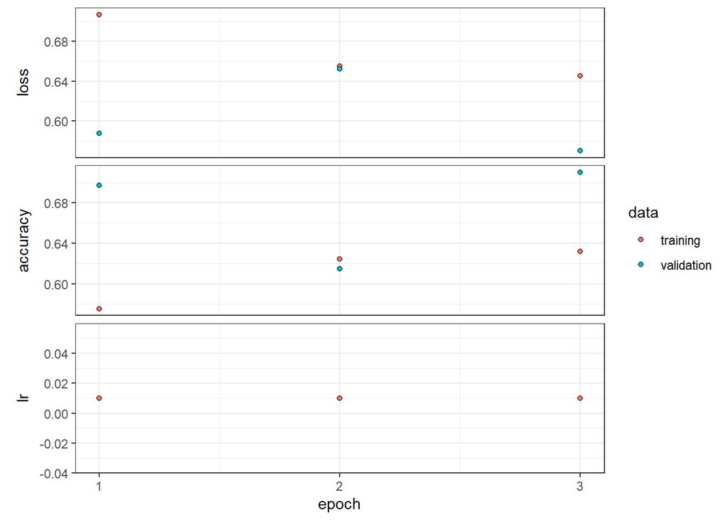

```r
# Data Preparation

## Clean environment and load libraries

rm(list = ls())
options(scipen = 999)
library(keras)
library(tensorflow)
set_random_seed(42)
k_clear_session()

## Load data, normalize and split


fulldata <- read.csv(file = "C:/Users/kaspe/OneDrive - Aarhus Universitet/Skrivebord/BI/2. semester/Data science project/Data science project/modeling/Neural Network/Final_dataset.csv")


# Subset wins

win.df <- subset(fulldata, select = c("Winner","Winner_log"))


# Subset factor variables and turn them into dummies

library("fastDummies")
dummy.df <- subset(fulldata, select = c("Region", "Tournament", "Round", "Team1", "Team2"))
dummy.df <- dummy_cols(dummy.df, select_columns = c("Region", "Tournament", "Round", "Team1", "Team2"), remove_selected_columns = TRUE)


# Extract training observations for calculating mean and sd used for scaling. Then subset numerical variables

train.df <- subset(fulldata, subset = Tournament != "Worlds 2021 Main Event")

# Calculate mean and std for the numeric variables
mean <- apply(train.df[,10:ncol(train.df)], 2, mean)
std <- apply(train.df[,10:ncol(train.df)], 2, sd)

# Scale the whole dataset on train mean and train std
numeric.df <- as.data.frame(scale(fulldata[,10:ncol(fulldata)], center = mean, scale = std))


# Bind win.df, dummy.df and numeric.df together
fulldata.scaled <- cbind(win.df, numeric.df, dummy.df)

# Split into train and test

train.df <- subset(fulldata.scaled, subset = Region_Worlds == 0)
test.df <- subset(fulldata.scaled, subset = Region_Worlds == 1)
# The data is now split between train and test properly

# Create tensors

library(dplyr)

# x tensors

x_train <- select(train.df, -c("Winner", "Winner_log", "Team1Gold", "Team2Gold", "Team1Barons", "Team2Barons", "Team1Turrets", "Team2Turrets",
                               "Team1Kills", "Team2Kills"))
x_train <- select(x_train, -ends_with(c("Gold", "DtC")))
x_train <- as.matrix(x_train)

x_test <- select(test.df, -c("Winner", "Winner_log", "Team1Gold", "Team2Gold", "Team1Barons", "Team2Barons", "Team1Turrets", "Team2Turrets",
                             "Team1Kills", "Team2Kills"))
x_test <- select(x_test, -ends_with(c("Gold", "DtC")))
x_test <- as.matrix(x_test)

# y tensors

y_train <- as.array(train.df[,c("Winner_log")])
y_test <- as.array(test.df[,c("Winner_log")])


# Define convenience function:

get_val_scores <- function(history){

  min_loss <-  min(history$metrics$val_loss)
  min_epoch <- which.min(history$metrics$val_loss)
  min_acc <- history$metrics$val_accuracy[which.min(history$metrics$val_loss)]

  cat('Minimum validation loss:  ')
  cat(min_loss)
  cat('\n')

  cat('Loss minimized at epoch:  ')
  cat(min_epoch)
  cat('\n')

  cat('Validation accuracy:      ')
  cat(min_acc)
  cat('\n')

  return(list(min_loss = min_loss,
              min_epoch = min_epoch,
              min_acc = min_acc))

}


# Hyperparameter flags

# set flags for hyperparameters of interest (default values in ())
FLAGS <- flags(
  flag_integer("units1", 256),
  flag_integer("units2", 128),
  flag_integer("units3", 32),
  flag_integer("units4", 16),
  flag_integer("units5", 8),
  flag_integer("units6", 8),
  flag_integer("batch_size", 50),
  flag_numeric("learning_rate", 0.01),
  flag_numeric("dropout", 0),
  flag_numeric("weight_decay", 0)
)

# Define Model

# Create a model with a single hidden input layer
model <- keras_model_sequential() %>%
  layer_dense(units = FLAGS$units1, activation = "relu", input_shape = ncol(x_train),
              kernel_regularizer = regularizer_l2(l = FLAGS$weight_decay)) %>%
  layer_dropout(rate = FLAGS$dropout) %>%
  layer_dense(units = FLAGS$units2, activation = "relu",
              kernel_regularizer = regularizer_l2(l = FLAGS$weight_decay)) %>%
  layer_dropout(rate = FLAGS$dropout) %>%
  layer_dense(units = FLAGS$units3, activation = "relu",
              kernel_regularizer = regularizer_l2(l = FLAGS$weight_decay)) %>%
  layer_dropout(rate = FLAGS$dropout) %>%
  layer_dense(units = FLAGS$units4, activation = "relu",
              kernel_regularizer = regularizer_l2(l = FLAGS$weight_decay)) %>%
  layer_dropout(rate = FLAGS$dropout) %>%
  layer_dense(units = FLAGS$units5, activation = "relu",
              kernel_regularizer = regularizer_l2(l = FLAGS$weight_decay)) %>%
  layer_dropout(rate = FLAGS$dropout) %>%
  layer_dense(units = FLAGS$units6, activation = "relu",
              kernel_regularizer = regularizer_l2(l = FLAGS$weight_decay)) %>%
  layer_dropout(rate = FLAGS$dropout) %>%
  layer_dense(units = 1, activation = "sigmoid") # Final output layer


# Add compile step
model %>% compile(
  optimizer_rmsprop(FLAGS$learning_rate),
  loss = "binary_crossentropy",
  metrics = c("accuracy")
)
model
## Model: "sequential"
## ________________________________________________________________________________
##  Layer (type)                       Output Shape                    Param #
## ================================================================================
##  dense_6 (Dense)                    (None, 256)                     52224
##
##  dropout_5 (Dropout)                (None, 256)                     0
##
##  dense_5 (Dense)                    (None, 128)                     32896
##
##  dropout_4 (Dropout)                (None, 128)                     0
##
##  dense_4 (Dense)                    (None, 32)                      4128
##
##  dropout_3 (Dropout)                (None, 32)                      0
##
##  dense_3 (Dense)                    (None, 16)                      528
##
##  dropout_2 (Dropout)                (None, 16)                      0
##
##  dense_2 (Dense)                    (None, 8)                       136
##
##  dropout_1 (Dropout)                (None, 8)                       0
##
##  dense_1 (Dense)                    (None, 8)                       72
##
##  dropout (Dropout)                  (None, 8)                       0
##
##  dense (Dense)                      (None, 1)                       9
##
## ================================================================================
## Total params: 89,993
## Trainable params: 89,993
## Non-trainable params: 0
## ________________________________________________________________________________
# Train model
history <- model %>% fit(
  x_train,
  y_train,
  epochs = 3,
  batch_size = FLAGS$batch_size,
  validation_split = 0.2,
  verbose = 0,
  callbacks = list(
    callback_reduce_lr_on_plateau(patience = 2, factor = 0.1),
    callback_early_stopping(patience = 20,
                            restore_best_weights = TRUE,
                            min_delta = 0.0001)
  )
)


# Report minimum loss

# Evaluation measures and plot

get_val_scores(history)
## Minimum validation loss:  0.5702305
## Loss minimized at epoch:  3
## Validation accuracy:      0.7099567
## $min_loss
## [1] 0.5702305
##
## $min_epoch
## [1] 3
##
## $min_acc
## [1] 0.7099567
plot(history)
```

```r
model %>% save_model_hdf5("traintestmodel")
```

## Run model on test data

Run the final production model on the test data and print test loss and test accuracy.

```r
results <- model %>% evaluate(x_test, y_test)
results
```

```
##      loss  accuracy
## 0.6896449 0.6202531
```

Now, generate the likelihood of games won by team 2 by using the predict method:

```r
model %>% predict(x_test)
```

```
##            [,1]
##  [1,] 0.3909477
##  [2,] 0.3472586
##  [3,] 0.6633000
##  [4,] 0.5480222
##  [5,] 0.2148001
##  [6,] 0.4834194
##  [7,] 0.6378418
##  [8,] 0.4234484
##  [9,] 0.3875155
## [10,] 0.5840040
## [11,] 0.4201071
## [12,] 0.6955886
## [13,] 0.5583845
## [14,] 0.6612653
```

[output cut: 65 more lines]